# Risk Factor Analysis

## Outcome Variable

**Outcome Variable:** sstunted

## Predictor Variables

**Intervention Variable:** vagbrth

**Adjustment Set:**

- arm
- sex
- W_mage
- meducyrs
- feducyrs
- hhwealth_quart
- W_mhtcm
- W_mwtkg
- W_mbmi
- single
- W_nrooms
- brthmon
- W_parity
- impfloor
- delta_W_mage
- delta_meducyrs
- delta_feducyrs
- delta_hhwealth_quart
- delta_W_mhtcm
- delta_W_mwtkg
- delta_W_mbmi
- delta_single
- delta_W_nrooms
- delta_brthmon
- delta_W_parity
- delta_impfloor

## Stratifying Variables

The analysis was stratified on these variable(s):

- agecat
- studyid
- country

## Data Summary

| agecat | studyid | country | vagbrth | sstunted | n_cell | n |
| --- | --- | --- | --- | --- | --- | --- |
| Birth | ki1000108-CMC-V-BCS-2002 | INDIA | 0 | 0 | 10 | 92 |
| Birth | ki1000108-CMC-V-BCS-2002 | INDIA | 0 | 1 | 1 | 92 |
| Birth | ki1000108-CMC-V-BCS-2002 | INDIA | 1 | 0 | 78 | 92 |
| Birth | ki1000108-CMC-V-BCS-2002 | INDIA | 1 | 1 | 3 | 92 |
| Birth | ki1000108-IRC | INDIA | 0 | 0 | 67 | 388 |
| Birth | ki1000108-IRC | INDIA | 0 | 1 | 1 | 388 |
| Birth | ki1000108-IRC | INDIA | 1 | 0 | 305 | 388 |
| Birth | ki1000108-IRC | INDIA | 1 | 1 | 15 | 388 |
| Birth | ki1017093b-PROVIDE | BANGLADESH | 0 | 0 | 107 | 539 |
| Birth | ki1017093b-PROVIDE | BANGLADESH | 0 | 1 | 1 | 539 |
| Birth | ki1017093b-PROVIDE | BANGLADESH | 1 | 0 | 428 | 539 |
| Birth | ki1017093b-PROVIDE | BANGLADESH | 1 | 1 | 3 | 539 |
| Birth | ki1017093c-NIH-Crypto | BANGLADESH | 0 | 0 | 185 | 477 |
| Birth | ki1017093c-NIH-Crypto | BANGLADESH | 0 | 1 | 1 | 477 |
| Birth | ki1017093c-NIH-Crypto | BANGLADESH | 1 | 0 | 290 | 477 |
| Birth | ki1017093c-NIH-Crypto | BANGLADESH | 1 | 1 | 1 | 477 |
| Birth | ki1119695-PROBIT | BELARUS | 0 | 0 | 1596 | 13890 |
| Birth | ki1119695-PROBIT | BELARUS | 0 | 1 | 1 | 13890 |
| Birth | ki1119695-PROBIT | BELARUS | 1 | 0 | 12289 | 13890 |
| Birth | ki1119695-PROBIT | BELARUS | 1 | 1 | 4 | 13890 |
| Birth | ki1126311-ZVITAMBO | ZIMBABWE | 0 | 0 | 1136 | 13761 |
| Birth | ki1126311-ZVITAMBO | ZIMBABWE | 0 | 1 | 30 | 13761 |
| Birth | ki1126311-ZVITAMBO | ZIMBABWE | 1 | 0 | 12191 | 13761 |
| Birth | ki1126311-ZVITAMBO | ZIMBABWE | 1 | 1 | 404 | 13761 |
| Birth | kiGH5241-JiVitA-3 | BANGLADESH | 0 | 0 | 501 | 22418 |
| Birth | kiGH5241-JiVitA-3 | BANGLADESH | 0 | 1 | 38 | 22418 |
| Birth | kiGH5241-JiVitA-3 | BANGLADESH | 1 | 0 | 19471 | 22418 |
| Birth | kiGH5241-JiVitA-3 | BANGLADESH | 1 | 1 | 2408 | 22418 |
| Birth | kiGH5241-JiVitA-4 | BANGLADESH | 0 | 0 | 73 | 2822 |
| Birth | kiGH5241-JiVitA-4 | BANGLADESH | 0 | 1 | 3 | 2822 |

[output cut: 74 more lines]

The following strata were considered:

- agecat: 24 months, studyid: ki1000108-CMC-V-BCS-2002, country: INDIA
- agecat: 24 months, studyid: ki1000108-IRC, country: INDIA
- agecat: 24 months, studyid: ki1017093b-PROVIDE, country: BANGLADESH
- agecat: 24 months, studyid: ki1017093c-NIH-Crypto, country: BANGLADESH
- agecat: 24 months, studyid: ki1066203-TanzaniaChild2, country: TANZANIA, UNITED REPUBLIC OF
- agecat: 24 months, studyid: ki1119695-PROBIT, country: BELARUS
- agecat: 24 months, studyid: ki1126311-ZVITAMBO, country: ZIMBABWE
- agecat: 24 months, studyid: kiGH5241-JiVitA-3, country: BANGLADESH
- agecat: 24 months, studyid: kiGH5241-JiVitA-4, country: BANGLADESH
- agecat: 6 months, studyid: ki1000108-CMC-V-BCS-2002, country: INDIA
- agecat: 6 months, studyid: ki1000108-IRC, country: INDIA
- agecat: 6 months, studyid: ki1017093b-PROVIDE, country: BANGLADESH
- agecat: 6 months, studyid: ki1017093c-NIH-Crypto, country: BANGLADESH
- agecat: 6 months, studyid: ki1066203-TanzaniaChild2, country: TANZANIA, UNITED REPUBLIC OF
- agecat: 6 months, studyid: ki1119695-PROBIT, country: BELARUS
- agecat: 6 months, studyid: ki1126311-ZVITAMBO, country: ZIMBABWE
- agecat: 6 months, studyid: kiGH5241-JiVitA-3, country: BANGLADESH
- agecat: 6 months, studyid: kiGH5241-JiVitA-4, country: BANGLADESH
- agecat: Birth, studyid: ki1000108-CMC-V-BCS-2002, country: INDIA
- agecat: Birth, studyid: ki1000108-IRC, country: INDIA
- agecat: Birth, studyid: ki1017093b-PROVIDE, country: BANGLADESH
- agecat: Birth, studyid: ki1017093c-NIH-Crypto, country: BANGLADESH
- agecat: Birth, studyid: ki1119695-PROBIT, country: BELARUS
- agecat: Birth, studyid: ki1126311-ZVITAMBO, country: ZIMBABWE
- agecat: Birth, studyid: kiGH5241-JiVitA-3, country: BANGLADESH
- agecat: Birth, studyid: kiGH5241-JiVitA-4, country: BANGLADESH

### Dropped Strata

Some strata were dropped due to rare outcomes:

- agecat: Birth, studyid: ki1000108-CMC-V-BCS-2002, country: INDIA
- agecat: Birth, studyid: ki1000108-IRC, country: INDIA
- agecat: Birth, studyid: ki1017093b-PROVIDE, country: BANGLADESH
- agecat: Birth, studyid: ki1017093c-NIH-Crypto, country: BANGLADESH
- agecat: Birth, studyid: ki1119695-PROBIT, country: BELARUS
- agecat: Birth, studyid: kiGH5241-JiVitA-4, country: BANGLADESH
- agecat: 6 months, studyid: ki1000108-CMC-V-BCS-2002, country: INDIA
- agecat: 6 months, studyid: ki1017093b-PROVIDE, country: BANGLADESH
- agecat: 6 months, studyid: ki1017093c-NIH-Crypto, country: BANGLADESH
- agecat: 6 months, studyid: ki1066203-TanzaniaChild2, country: TANZANIA, UNITED REPUBLIC OF
- agecat: 24 months, studyid: ki1000108-IRC, country: INDIA
- agecat: 24 months, studyid: ki1066203-TanzaniaChild2, country: TANZANIA, UNITED REPUBLIC OF

## Methods Detail

We’re interested in the causal parameters $E[Y_a]$ for all values of $a \in \mathcal{A}$. These parameters represent the mean outcome if, possibly contrary to fact, we intervened to set all units to have $A=a$. Under the randomization and positivity assumptions, these are identified by the statistical parameters $\psi_a=E_W[E_{Y|A,W}(Y|A=a,W)]$. In addition, we’re interested in the mean of $Y$, $E[Y]$ under no intervention (the observed mean). We will estimate these parameters by using SuperLearner to fit the relevant likelihood factors – $E_{Y|A,W}(Y|A=a,W)$ and $p(A=a|W)$, and then updating our likelihood fit using a joint TMLE.

For unadjusted analyses ($W=\{\}$), initial likelihoods were estimated using Lrnr_glm to estimate the simple $E(Y|A)$ and Lrnr_mean to estimate $p(A)$. For adjusted analyses, a small library containing Lrnr_glmnet, Lrnr_xgboost, and Lrnr_mean was used.

Having estimated these parameters, we will then use the delta method to estimate relative risks and attributable risks relative to a prespecified baseline level of $A$.

# Results Detail

## Results Plots

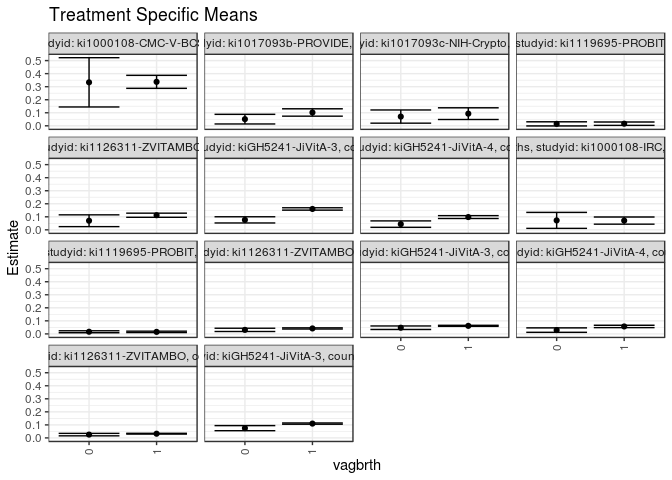

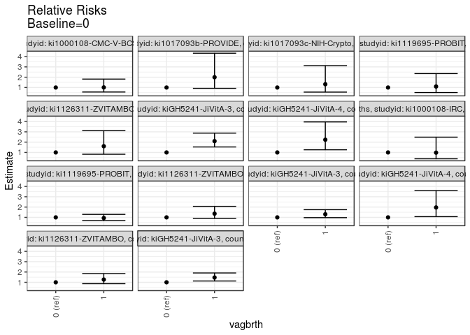

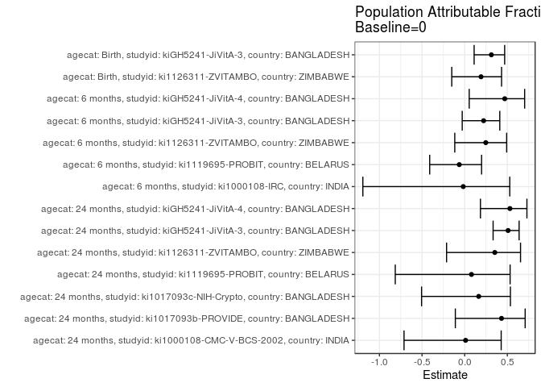

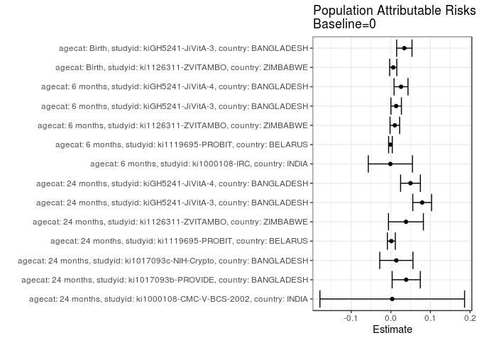

## Results Table

### Parameter: TSM

| agecat | studyid | country | intervention_level | baseline_level | estimate | ci_lower | ci_upper |
| --- | --- | --- | --- | --- | --- | --- | --- |
| Birth | ki1126311-ZVITAMBO | ZIMBABWE | 0 | NA | 0.0254951 | 0.0161577 | 0.0348326 |
| Birth | ki1126311-ZVITAMBO | ZIMBABWE | 1 | NA | 0.0322780 | 0.0291867 | 0.0353693 |
| Birth | kiGH5241-JiVitA-3 | BANGLADESH | 0 | NA | 0.0749757 | 0.0555225 | 0.0944290 |
| Birth | kiGH5241-JiVitA-3 | BANGLADESH | 1 | NA | 0.1099190 | 0.1052856 | 0.1145525 |
| 6 months | ki1000108-IRC | INDIA | 0 | NA | 0.0724638 | 0.0112169 | 0.1337106 |
| 6 months | ki1000108-IRC | INDIA | 1 | NA | 0.0710059 | 0.0435916 | 0.0984202 |
| 6 months | ki1119695-PROBIT | BELARUS | 0 | NA | 0.0163961 | 0.0088465 | 0.0239457 |
| 6 months | ki1119695-PROBIT | BELARUS | 1 | NA | 0.0153670 | 0.0099643 | 0.0207697 |
| 6 months | ki1126311-ZVITAMBO | ZIMBABWE | 0 | NA | 0.0307154 | 0.0181842 | 0.0432467 |
| 6 months | ki1126311-ZVITAMBO | ZIMBABWE | 1 | NA | 0.0417754 | 0.0373381 | 0.0462128 |
| 6 months | kiGH5241-JiVitA-3 | BANGLADESH | 0 | NA | 0.0472450 | 0.0338043 | 0.0606857 |
| 6 months | kiGH5241-JiVitA-3 | BANGLADESH | 1 | NA | 0.0615634 | 0.0575444 | 0.0655823 |
| 6 months | kiGH5241-JiVitA-4 | BANGLADESH | 0 | NA | 0.0290482 | 0.0119680 | 0.0461284 |
| 6 months | kiGH5241-JiVitA-4 | BANGLADESH | 1 | NA | 0.0570040 | 0.0479486 | 0.0660594 |
| 24 months | ki1000108-CMC-V-BCS-2002 | INDIA | 0 | NA | 0.3333333 | 0.1444810 | 0.5221856 |
| 24 months | ki1000108-CMC-V-BCS-2002 | INDIA | 1 | NA | 0.3371758 | 0.2873681 | 0.3869835 |
| 24 months | ki1017093b-PROVIDE | BANGLADESH | 0 | NA | 0.0510949 | 0.0141917 | 0.0879981 |
| 24 months | ki1017093b-PROVIDE | BANGLADESH | 1 | NA | 0.1020408 | 0.0737647 | 0.1303170 |
| 24 months | ki1017093c-NIH-Crypto | BANGLADESH | 0 | NA | 0.0707071 | 0.0201159 | 0.1212983 |
| 24 months | ki1017093c-NIH-Crypto | BANGLADESH | 1 | NA | 0.0931677 | 0.0481827 | 0.1381527 |
| 24 months | ki1119695-PROBIT | BELARUS | 0 | NA | 0.0148305 | -0.0010089 | 0.0306699 |
| 24 months | ki1119695-PROBIT | BELARUS | 1 | NA | 0.0162784 | 0.0034501 | 0.0291067 |
| 24 months | ki1126311-ZVITAMBO | ZIMBABWE | 0 | NA | 0.0699139 | 0.0246396 | 0.1151881 |
| 24 months | ki1126311-ZVITAMBO | ZIMBABWE | 1 | NA | 0.1120405 | 0.0960561 | 0.1280248 |
| 24 months | kiGH5241-JiVitA-3 | BANGLADESH | 0 | NA | 0.0763621 | 0.0525848 | 0.1001395 |
| 24 months | kiGH5241-JiVitA-3 | BANGLADESH | 1 | NA | 0.1601861 | 0.1511567 | 0.1692156 |
| 24 months | kiGH5241-JiVitA-4 | BANGLADESH | 0 | NA | 0.0438919 | 0.0192878 | 0.0684959 |
| 24 months | kiGH5241-JiVitA-4 | BANGLADESH | 1 | NA | 0.0980074 | 0.0870261 | 0.1089888 |

### Parameter: E(Y)

| agecat | studyid | country | intervention_level | baseline_level | estimate | ci_lower | ci_upper |
| --- | --- | --- | --- | --- | --- | --- | --- |
| Birth | ki1126311-ZVITAMBO | ZIMBABWE | NA | NA | 0.0315384 | 0.0286183 | 0.0344585 |
| Birth | kiGH5241-JiVitA-3 | BANGLADESH | NA | NA | 0.1091088 | 0.1045539 | 0.1136636 |
| 6 months | ki1000108-IRC | INDIA | NA | NA | 0.0712531 | 0.0462303 | 0.0962759 |
| 6 months | ki1119695-PROBIT | BELARUS | NA | NA | 0.0154178 | 0.0100323 | 0.0208033 |
| 6 months | ki1126311-ZVITAMBO | ZIMBABWE | NA | NA | 0.0408092 | 0.0366277 | 0.0449907 |
| 6 months | kiGH5241-JiVitA-3 | BANGLADESH | NA | NA | 0.0607220 | 0.0568736 | 0.0645704 |
| 6 months | kiGH5241-JiVitA-4 | BANGLADESH | NA | NA | 0.0547878 | 0.0463432 | 0.0632323 |
| 24 months | ki1000108-CMC-V-BCS-2002 | INDIA | NA | NA | 0.3369272 | 0.2887662 | 0.3850883 |
| 24 months | ki1017093b-PROVIDE | BANGLADESH | NA | NA | 0.0899654 | 0.0666186 | 0.1133122 |
| 24 months | ki1017093c-NIH-Crypto | BANGLADESH | NA | NA | 0.0846154 | 0.0507212 | 0.1185095 |
| 24 months | ki1119695-PROBIT | BELARUS | NA | NA | 0.0161090 | 0.0034156 | 0.0288025 |
| 24 months | ki1126311-ZVITAMBO | ZIMBABWE | NA | NA | 0.1080914 | 0.0929623 | 0.1232206 |
| 24 months | kiGH5241-JiVitA-3 | BANGLADESH | NA | NA | 0.1555219 | 0.1467695 | 0.1642743 |
| 24 months | kiGH5241-JiVitA-4 | BANGLADESH | NA | NA | 0.0935323 | 0.0832327 | 0.1038320 |

### Parameter: RR

| agecat | studyid | country | intervention_level | baseline_level | estimate | ci_lower | ci_upper |
| --- | --- | --- | --- | --- | --- | --- | --- |
| Birth | ki1126311-ZVITAMBO | ZIMBABWE | 0 | 0 | 1.0000000 | 1.0000000 | 1.000000 |
| Birth | ki1126311-ZVITAMBO | ZIMBABWE | 1 | 0 | 1.2660483 | 0.8670705 | 1.848613 |
| Birth | kiGH5241-JiVitA-3 | BANGLADESH | 0 | 0 | 1.0000000 | 1.0000000 | 1.000000 |
| Birth | kiGH5241-JiVitA-3 | BANGLADESH | 1 | 0 | 1.4660616 | 1.1275431 | 1.906212 |
| 6 months | ki1000108-IRC | INDIA | 0 | 0 | 1.0000000 | 1.0000000 | 1.000000 |
| 6 months | ki1000108-IRC | INDIA | 1 | 0 | 0.9798817 | 0.3869206 | 2.481564 |
| 6 months | ki1119695-PROBIT | BELARUS | 0 | 0 | 1.0000000 | 1.0000000 | 1.000000 |
| 6 months | ki1119695-PROBIT | BELARUS | 1 | 0 | 0.9372373 | 0.6791710 | 1.293362 |
| 6 months | ki1126311-ZVITAMBO | ZIMBABWE | 0 | 0 | 1.0000000 | 1.0000000 | 1.000000 |
| 6 months | ki1126311-ZVITAMBO | ZIMBABWE | 1 | 0 | 1.3600793 | 0.8923234 | 2.073033 |
| 6 months | kiGH5241-JiVitA-3 | BANGLADESH | 0 | 0 | 1.0000000 | 1.0000000 | 1.000000 |
| 6 months | kiGH5241-JiVitA-3 | BANGLADESH | 1 | 0 | 1.3030655 | 0.9720268 | 1.746845 |
| 6 months | kiGH5241-JiVitA-4 | BANGLADESH | 0 | 0 | 1.0000000 | 1.0000000 | 1.000000 |
| 6 months | kiGH5241-JiVitA-4 | BANGLADESH | 1 | 0 | 1.9623946 | 1.0695813 | 3.600467 |
| 24 months | ki1000108-CMC-V-BCS-2002 | INDIA | 0 | 0 | 1.0000000 | 1.0000000 | 1.000000 |
| 24 months | ki1000108-CMC-V-BCS-2002 | INDIA | 1 | 0 | 1.0115274 | 0.5632472 | 1.816587 |
| 24 months | ki1017093b-PROVIDE | BANGLADESH | 0 | 0 | 1.0000000 | 1.0000000 | 1.000000 |
| 24 months | ki1017093b-PROVIDE | BANGLADESH | 1 | 0 | 1.9970845 | 0.9213693 | 4.328717 |
| 24 months | ki1017093c-NIH-Crypto | BANGLADESH | 0 | 0 | 1.0000000 | 1.0000000 | 1.000000 |
| 24 months | ki1017093c-NIH-Crypto | BANGLADESH | 1 | 0 | 1.3176575 | 0.5558122 | 3.123755 |
| 24 months | ki1119695-PROBIT | BELARUS | 0 | 0 | 1.0000000 | 1.0000000 | 1.000000 |
| 24 months | ki1119695-PROBIT | BELARUS | 1 | 0 | 1.0976304 | 0.5128046 | 2.349418 |
| 24 months | ki1126311-ZVITAMBO | ZIMBABWE | 0 | 0 | 1.0000000 | 1.0000000 | 1.000000 |
| 24 months | ki1126311-ZVITAMBO | ZIMBABWE | 1 | 0 | 1.6025506 | 0.8260164 | 3.109101 |
| 24 months | kiGH5241-JiVitA-3 | BANGLADESH | 0 | 0 | 1.0000000 | 1.0000000 | 1.000000 |
| 24 months | kiGH5241-JiVitA-3 | BANGLADESH | 1 | 0 | 2.0977167 | 1.5319984 | 2.872337 |
| 24 months | kiGH5241-JiVitA-4 | BANGLADESH | 0 | 0 | 1.0000000 | 1.0000000 | 1.000000 |
| 24 months | kiGH5241-JiVitA-4 | BANGLADESH | 1 | 0 | 2.2329294 | 1.2581727 | 3.962869 |

### Parameter: PAR

| agecat | studyid | country | intervention_level | baseline_level | estimate | ci_lower | ci_upper |
| --- | --- | --- | --- | --- | --- | --- | --- |
| Birth | ki1126311-ZVITAMBO | ZIMBABWE | 0 | NA | 0.0060433 | -0.0029937 | 0.0150803 |
| Birth | kiGH5241-JiVitA-3 | BANGLADESH | 0 | NA | 0.0341330 | 0.0146951 | 0.0535710 |
| 6 months | ki1000108-IRC | INDIA | 0 | NA | -0.0012107 | -0.0569370 | 0.0545156 |
| 6 months | ki1119695-PROBIT | BELARUS | 0 | NA | -0.0009783 | -0.0056390 | 0.0036824 |
| 6 months | ki1126311-ZVITAMBO | ZIMBABWE | 0 | NA | 0.0100938 | -0.0020491 | 0.0222366 |
| 6 months | kiGH5241-JiVitA-3 | BANGLADESH | 0 | NA | 0.0134769 | 0.0002182 | 0.0267357 |
| 6 months | kiGH5241-JiVitA-4 | BANGLADESH | 0 | NA | 0.0257396 | 0.0081239 | 0.0433552 |
| 24 months | ki1000108-CMC-V-BCS-2002 | INDIA | 0 | NA | 0.0035939 | -0.1790816 | 0.1862693 |
| 24 months | ki1017093b-PROVIDE | BANGLADESH | 0 | NA | 0.0388705 | 0.0033552 | 0.0743858 |
| 24 months | ki1017093c-NIH-Crypto | BANGLADESH | 0 | NA | 0.0139083 | -0.0280339 | 0.0558505 |
| 24 months | ki1119695-PROBIT | BELARUS | 0 | NA | 0.0012785 | -0.0087765 | 0.0113336 |
| 24 months | ki1126311-ZVITAMBO | ZIMBABWE | 0 | NA | 0.0381776 | -0.0059275 | 0.0822826 |
| 24 months | kiGH5241-JiVitA-3 | BANGLADESH | 0 | NA | 0.0791598 | 0.0554251 | 0.1028944 |
| 24 months | kiGH5241-JiVitA-4 | BANGLADESH | 0 | NA | 0.0496405 | 0.0246670 | 0.0746140 |

### Parameter: PAF

| agecat | studyid | country | intervention_level | baseline_level | estimate | ci_lower | ci_upper |
| --- | --- | --- | --- | --- | --- | --- | --- |
| Birth | ki1126311-ZVITAMBO | ZIMBABWE | 0 | NA | 0.1916173 | -0.1516204 | 0.4325538 |
| Birth | kiGH5241-JiVitA-3 | BANGLADESH | 0 | NA | 0.3128349 | 0.1107660 | 0.4689859 |
| 6 months | ki1000108-IRC | INDIA | 0 | NA | -0.0169915 | -1.1942765 | 0.5286502 |
| 6 months | ki1119695-PROBIT | BELARUS | 0 | NA | -0.0634516 | -0.4104838 | 0.1981976 |
| 6 months | ki1126311-ZVITAMBO | ZIMBABWE | 0 | NA | 0.2473403 | -0.1162817 | 0.4925146 |
| 6 months | kiGH5241-JiVitA-3 | BANGLADESH | 0 | NA | 0.2219451 | -0.0289057 | 0.4116376 |
| 6 months | kiGH5241-JiVitA-4 | BANGLADESH | 0 | NA | 0.4698052 | 0.0530835 | 0.7031348 |
| 24 months | ki1000108-CMC-V-BCS-2002 | INDIA | 0 | NA | 0.0106667 | -0.7113840 | 0.4280766 |
| 24 months | ki1017093b-PROVIDE | BANGLADESH | 0 | NA | 0.4320606 | -0.1095941 | 0.7093035 |
| 24 months | ki1017093c-NIH-Crypto | BANGLADESH | 0 | NA | 0.1643710 | -0.5055688 | 0.5362046 |
| 24 months | ki1119695-PROBIT | BELARUS | 0 | NA | 0.0793677 | -0.8142793 | 0.5328372 |
| 24 months | ki1126311-ZVITAMBO | ZIMBABWE | 0 | NA | 0.3531970 | -0.2124414 | 0.6549490 |
| 24 months | kiGH5241-JiVitA-3 | BANGLADESH | 0 | NA | 0.5089943 | 0.3333700 | 0.6383502 |
| 24 months | kiGH5241-JiVitA-4 | BANGLADESH | 0 | NA | 0.5307306 | 0.1848082 | 0.7298626 |